# IsyE 603 HW3

```r
#Problem 1c - Create the naive forecast for the validation period
library(forecast)
SouvenirSales.data <- read.csv(file ='SouvenirSales.csv', header = TRUE)
#creating the data in a time series format spanning from  Jan 1995 to  Dec. 2001 using a freq of 12
Sales.ts <- ts(SouvenirSales.data$Sales, start = c(1995,1), end = c(2001, 12), freq = 12)
# h should be the same as validation period if we want to make a validation prediction.
fixed.nValid <- 12
# ssince we have a fixed valid the rest will be training.
fixed.nTrain <- length(Sales.ts) - fixed.nValid
#training period
train.ts <- window(Sales.ts, start = c(1995, 1), end = c(1995, fixed.nTrain))
#validation period
valid.ts <- window(Sales.ts, start = c(1995, fixed.nTrain + 1), end = c(1995, fixed.nTrain + fixed.nValid))
#h is the horizon that is the values we want to forecost in the future. In this case 12 month ahead so I set h = 12
naive.fixed <- naive(train.ts, h = fixed.nValid)
#naive roll is a one step way of doing naive prediction
#naive.roll <- ts(SouvenirSales.data$Sales[fixed.nTrain:(fixed.nTrain + fixed.nValid - 1)], start = c(1995, fixed.nTrain + 1), end = c(1995, fixed.nTrain + fixed.nValid), freq = 12)
#naive.roll
naive.fixed$mean
```

```
          Jan      Feb      Mar      Apr      May      Jun      Jul      Aug      Sep
2001 80721.71 80721.71 80721.71 80721.71 80721.71 80721.71 80721.71 80721.71 80721.71
          Oct      Nov      Dec
2001 80721.71 80721.71 80721.71
```

```r
#problem 1d - computing root mean square error and mean absolute percent error
stepsAhead <- 12 #roll ahead #
error <- rep(0, fixed.nValid - stepsAhead + 1)
percent.error <- rep(0, fixed.nValid - stepsAhead + 1)
for(j in fixed.nTrain:(fixed.nTrain + fixed.nValid - stepsAhead)) {
  train.ts <- window(Sales.ts, start = c(1995, 1), end = c(1995, j))
  valid.ts <- window(Sales.ts, start = c(1995, j + stepsAhead), end = c(1995, j + stepsAhead))
  naive.fixed <- naive(train.ts, h = stepsAhead)
  error[j - fixed.nTrain + 1] <- valid.ts - naive.fixed$mean[stepsAhead]
  percent.error[j - fixed.nTrain + 1] <- error[j - fixed.nTrain + 1] / valid.ts
}
sqrt(mean(error^2)) #RMSE
```

```
[1] 23938.96
```

```r
mean(abs(percent.error))#MAPE
```

```
[1] 0.2287293
```

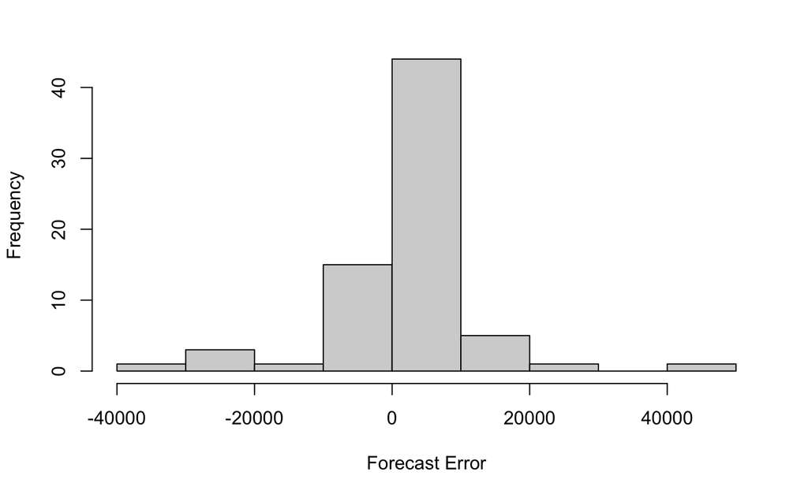

```r
#Problem 1e
#Historgram of the forecast errors
hist(naive.fixed$residuals, ylab = "Frequency", xlab = "Forecast Error", bty = "l", main = "")
```

```r
#Plotting actual sales vs forecasted sales
plot(train.ts, ylim = c(1600, 106000),  ylab = "Sales", xlab = "Time", bty = "l", xaxt = "n", xlim = c(1995,2003.25), main = "Actual Sales vs Forecasted Sales")
axis(1, at = seq(1995, 2003, 1), labels = format(seq(1995, 2003, 1)))
```

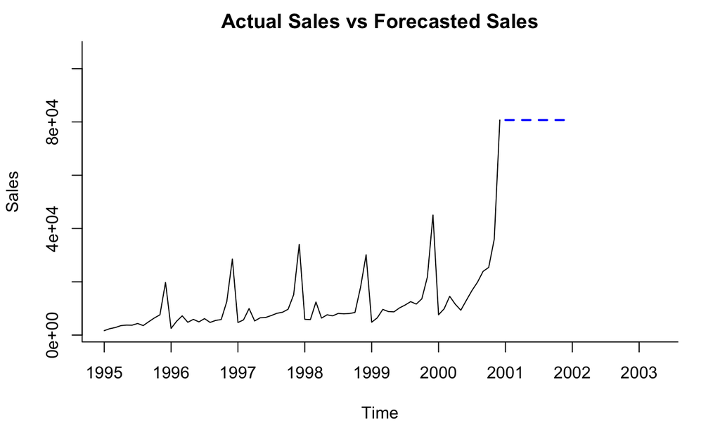

```r
lines(naive.fixed$mean, lwd = 2, col = "blue", lty = 2)
lines(valid.ts)
```

```r
NA
NA
NA
NA
NA
```

## Problem 1a

The data was partitioned in order to assess the prediction error which is useful for evaluating the performance of a model.

## Problem 1b

The analyst chose a 12 month validation period since the priority is to forecast the sales for the next 12 months and the validation period should echo the forecost horizon (h).

##Problem 1e The actual sales in the year 2001 is different from the naive forecast in 2001.

##Problem 1f The analyst will have to combine the validation and training data sets together again in order to make a forecast for 2002. This is because thevalidation data set contains most resent data and will be beneficial for making a more accurate forecast.

```r
#Problem 2a - Plotting a time series plot for pre sept 11
#The sept11 ts data (time series) has to first be split into pre and post sept 11
library(dplyr)
library(tidyverse)
library(readxl) #reading an xls file in
Sept11.data <- read_excel("Sept11Travel.xls") #read my file in as xls
str(Sept11.data ) #Checking Structure of my data
```

```
tibble [172 × 4] (S3: tbl_df/tbl/data.frame)
 $ Month         : POSIXct[1:172], format: "1990-01-01" "1990-02-01" "1990-03-01" ...
 $ Air RPM (000s): num [1:172] 35153577 32965187 39993913 37981886 38419672 ...
 $ Rail PM       : num [1:172] 4.54e+08 4.35e+08 5.68e+08 5.68e+08 5.40e+08 ...
 $ VMT (billions): num [1:172] 163 153 178 179 189 ...
```

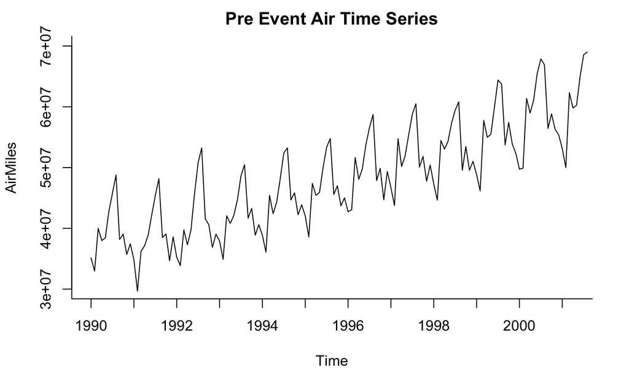

```r
#Created a time series data before 911 which is between Jan 1990 to Aug 2001
AirMiles.ts<-ts(Sept11.data$`Air RPM (000s)`, start = c(1990,1), end = c(2001, 8), frequency = 12)
plot.ts(AirMiles.ts, ylim = c(30000000, 70000000),  ylab = "AirMiles", xlab = "Time", bty = "l", xaxt = "n", xlim = c(1990,2001.25), main = "Pre Event Air Time Series")
axis(1, at = seq(1990, 2001, 1), labels = format(seq(1990, 2001, 1)))
```

```r
NA
NA
NA
NA
NA
```

## Problem 2a

The following time series components are present from the plot Level Trend Seasonality Random Noise

##Problem 2b Holt-Winter’s exponential smoothing should be used because the Winter method is adequate for forecasting a time series with both seasonality and trend.

```r
##Problem 3b(i) - Generating 4 quarters ahead by partitioning data such that validation period represents the last four quarters
#Run the forecaster approach of the Holt-Winter smoothing on the data using alpha = 0.2, beta = 0.15 and gamma = 0.05
library(forecast)
DeptSales.data <- read.csv(file = 'DepartmentStoreSales.csv', header = TRUE)
str(DeptSales.data)
```

```
'data.frame':   24 obs. of  2 variables:
 $ Quarter: int  1 2 3 4 5 6 7 8 9 10 ...
 $ Sales  : int  50147 49325 57048 76781 48617 50898 58517 77691 50862 53028 ...
```

```r
DeptSales.ts <- ts(DeptSales.data$Sales, frequency = 4) #frequency is 4  for quarterly
# set to 4 ofr last 4 quarters
Validlength <-4
#Since last 4 is valid rest will be train
TrainLength <- length(DeptSales.ts) - Validlength
DeptSaletrain.ts <- window(DeptSales.ts, end = c(1, TrainLength))
#validation period
DeptSalevalid.ts <- window(DeptSales.ts, start = c(1, TrainLength+ 1),  end = c(1, TrainLength + Validlength))
#adding ets (error , trend, seasonality), "ZZZ" - is for automated model selection.
DeptSale.HoltWint <-ets(DeptSaletrain.ts, model = "ZZZ", alpha = 0.2, beta = 0.15, gamma = 0.05)
DeptSales.Forecast <- forecast(DeptSale.HoltWint, h = Validlength, level = 0)
plot(DeptSales.Forecast, ylim = c(48000, 105000),  ylab = "Sales", xlab = "Time", bty = "l", xaxt = "n", xlim = c(1,7), main = "Quarterly Department Store Sales")
#adding x axis
axis(1, at = seq(1, 7, 1), labels = format(seq(1, 7, 1)))
```

```r
lines(DeptSales.Forecast$fitted, lwd = 2, col = "blue")
lines(DeptSales.Forecast$mean, lwd = 2, lty = 2, col = "blue" )
```

```r
##Problem 3b(ii) - Compute the MAPE(mean absolute percent error) for Q21- 22 of the validation period
#Note: I am using the forecast from my Hotlt winter forecast above.
#Quarter 21
Quarter21 <- window(DeptSales.ts, start = c(1,21), end = c(1,21))
#This function below can estimate the errors needed for a ts
accuracy(DeptSales.Forecast, Quarter21)
```

```
                     ME     RMSE      MAE        MPE     MAPE      MASE        ACF1
Training set   609.5633 1447.180 1240.995  0.9315256 1.985092 0.3982014 0.008503999
Test set     -1315.1565 1315.156 1315.156 -2.1630863 2.163086 0.4219979          NA
```

```r
#Quarter 22
Quarter22 <- window(DeptSales.ts, start = c(1,22), end = c(1,22))
#This function below can estimate the errors needed for a ts
accuracy(DeptSales.Forecast, Quarter22)
```

```
                    ME      RMSE       MAE        MPE      MAPE      MASE        ACF1
Training set  609.5633 1447.1798 1240.9947  0.9315256 1.9850921 0.3982014 0.008503999
Test set     -471.6041  471.6041  471.6041 -0.7266627 0.7266627 0.1513249          NA
```

[figure not shown]

```r
#Problem 3d - Applying the differencing method
#Differencing using lag 1 and 4. Lag 1 removes trend. Lag 4 removes seasonality.
difflag1.ts <- diff(DeptSales.ts, lag =1) #removes trend
difflag4.ts <- diff(DeptSales.ts, lag =4) #removes seasonality
# twice difference to do opposite, removing seasonality then trend.
difflag4_1.ts <-diff(diff(DeptSales.ts, lag = 4), lag = 1)
par(mfrow = c(3,2))
```

```r
plot(DeptSales.ts, ylab = "Sales", xlab = "Time", main = "Original Dept Sales Data")
plot(difflag1.ts, ylab = "Lag1Sales", xlab = "Time", main = "Dept Sales to Remove Trend ")
```

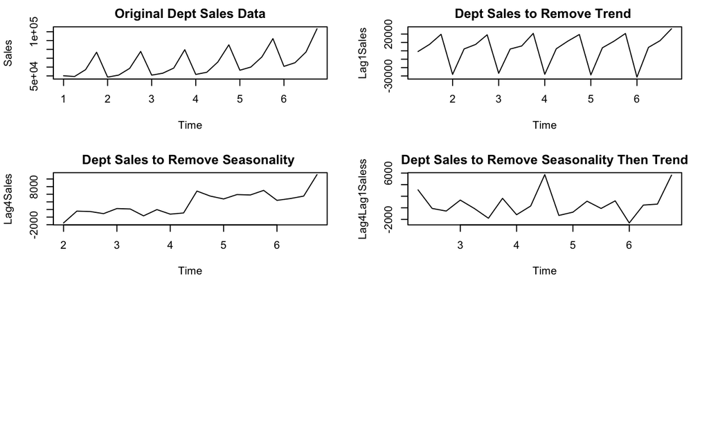

```r
plot(difflag4.ts, ylab = "Lag4Sales", xlab = "Time", main = "Dept Sales to Remove Seasonality ")
plot(difflag4_1.ts, ylab = "Lag4Lag1Saless", xlab = "Time", main = "Dept Sales to Remove Seasonality Then Trend")
```

```r
#Problem 3e -Forecasting 21-22 based on the average of the double differneced series in part d
#Training and validation datasets on the double difference from part d
DDiffTrain.ts <- window(difflag4_1.ts, end = c(1, TrainLength))
#validation period
DDiffValid.ts <- window(difflag4_1.ts, start = c(1, TrainLength+ 1),  end = c(1, TrainLength + Validlength))
## Setting up the mean point forecast using the training period
meanpointForecasts <- meanf(DDiffTrain.ts, h=4)
meanpointForecasts
```

|  | Point Forecast | Lo 80 | Hi 80 | Lo 95 | Hi 95 |
| --- | --- | --- | --- | --- | --- |
| 6 Q1 | 569.2 | -2116.935 | 3255.335 | -3714.114 | 4852.514 |
| 6 Q2 | 569.2 | -2116.935 | 3255.335 | -3714.114 | 4852.514 |
| 6 Q3 | 569.2 | -2116.935 | 3255.335 | -3714.114 | 4852.514 |
| 6 Q4 | 569.2 | -2116.935 | 3255.335 | -3714.114 | 4852.514 |

```r
#To get the actual forecast you need to de-difference the forecast
actualForecasts <- vector()

for (i in 1:Validlength) {
  if(i == 1) {
    actualForecasts[i] <- meanpointForecasts$mean[i] + DeptSaletrain.ts[(TrainLength+i)-Validlength] + (DeptSaletrain.ts[TrainLength] - DeptSaletrain.ts[TrainLength - Validlength])
  }
  else {
    actualForecasts[i] <- meanpointForecasts$mean[i] + DeptSaletrain.ts[(TrainLength+i)-Validlength] + (actualForecasts[i-1] - DeptSaletrain.ts[TrainLength+i-1-Validlength])
  }
}
#print actual  forecast after de-differencing
actualForecasts
```

```
[1]  63982.2  68177.4  80201.6 101467.8
```

```r
#estimating the MAPE for the actual forecasts in the difference method
accuracy(actualForecasts, DeptSalevalid.ts)
```

```
               ME    RMSE     MAE       MPE     MAPE        ACF1 Theil's U
Test set -1948.75 2942.41 2883.35 -3.159236 4.063656 -0.07650809 0.1948234
```

## Pronlem 3a

Moving average of raw series - Not suitable since plot contains trend and seasonality Moving average of deseasonalized series - Not suitable because even if the season is removed. The trend is the still present. Simple exponential smoothing of the raw series - Not suitable because plot has trend and seasonality. Double exponential smoothing of the raw series - Not suitable because the plot has seasonaility. Holt-Winter’s exponential smoothing - Suitable for plots with trends and seasonality.

##Problem 3b(ii) Note: The test set is the same as the validation period in this case. MAPE for the Q21 training set is 1.99 and the test set is 2.16 MAPE for the Q22 training set is 1.99 and the test set is 0.73

##Problem 3c From part b and the two plots provided, it can be concluded that the Holt-Winter Method is suitable for forecasting Q21 and Q22 because it captures the trend and seasonality of the data and the values of MAPE are low.

##Problem 3d From the plots above, the order of differncing does not matter. So, removing trend or seasonality first does not matter in this case.

## Problem 3f

I would choose the Holt-Winter’s method because it was easier to execute than the differencing method. Also, the MAPE generated using the differencing methos id 4.06 which is much higher than the error generated using the Holt-Winter’s method.

## Problem 3g

From the textbook, the simplest approach that can be used is the naive forecast. In this case there is seasonality to our data so we can use the seasonality naive forecast method as a baseline to compare all the other forecasts.

```r
#Problem 4a
library(fpp3)# Estimatiing the alpha and l0 for the number of pigs slaughtered in Victoria
#Filtering data for Pigs and victoria
Vicpigsdata<-aus_livestock %>%
  filter(State == 'Victoria',
         Animal == 'Pigs')

#Getting the parameters
fit<-Vicpigsdata %>%
  model(ETS(Count~error("A") + trend("N") + season("N")))

report(fit)
```

```
Series: Count
Model: ETS(A,N,N)
  Smoothing parameters:
    alpha = 0.3221247

  Initial states:
     l[0]
 100646.6

  sigma^2:  87480760

     AIC     AICc      BIC
13737.10 13737.14 13750.07
```

```r
dataforecast <- fit %>%
  forecast(h = 4)
dataforecast
```

| Animal | State | .model | Month | Count | .mean |
| --- | --- | --- | --- | --- | --- |
| Pigs | Victoria | ETS(Count ~ error("A") + trend("N") + season("N")) | 2019 Jan |  | 95186.56 |
| Pigs | Victoria | ETS(Count ~ error("A") + trend("N") + season("N")) | 2019 Feb |  | 95186.56 |
| Pigs | Victoria | ETS(Count ~ error("A") + trend("N") + season("N")) | 2019 Mar |  | 95186.56 |
| Pigs | Victoria | ETS(Count ~ error("A") + trend("N") + season("N")) | 2019 Apr |  | 95186.56 |

```r
#Problem 4b
# yhat is the mean - predicted value
yhat <- mean(dataforecast$.mean[1])

# Applying  augment function to get the residuals
augfit <- augment(fit)

# Estimating the standard deviation based on the residuals from augment function
s <- sd(augfit$.resid)

# Calculating the 95% prediction intervals
upper_lim_95 <- yhat + (s * 1.96)
lower_lim_95 <- yhat - (s * 1.96)

int_95 <- c(lower_lim_95, upper_lim_95)

# Printing interval values
int_95
```

```
[1]  76871.01 113502.10
```

```r
#Calculated intervals regularly.
# Calculating the 95% intervals for the model forecasts
dataforecast_hilo <- dataforecast%>% hilo()

# Output model interval values
dataforecast_hilo$`95%`[1]
```

```
<hilo[1]>
[1] [76854.79, 113518.3]95
```

##Problem 4a

Alpha = 0.322 l0 = 100646.6

The forecasted value for 4 months is the same all through. Value = 95186.56

##Problem 4b

The values are pretty similar for the one manually calculated and the one generated from R. However, the R generated calculated values have a slightly higher 95% confidence intervals.

```r
#Problem 5a - goog stock data
library(forecast)
GoogStock.data <- read.csv(file = 'goog_stock.csv', header = TRUE)
GoogStock.ts <- ts(GoogStock.data$x)
goog.train <- window(GoogStock.ts, end = 900)
goog.test <- window(GoogStock.ts, start = 901)
ses <- ets(goog.train, model = "ANN", alpha = 0.2)
ses
```

```
ETS(A,N,N)

Call:
 ets(y = goog.train, model = "ANN", alpha = 0.2)

  Smoothing parameters:
    alpha = 0.2

  Initial states:
    l = 400.1275

  sigma:  14.1996

     AIC     AICc      BIC
10899.94 10899.95 10909.54
```

```r
ses.pred <-forecast(ses, h = 100, level = 0)
ses.pred
```

|  | Point Forecast | Lo 0 | Hi 0 |
| --- | --- | --- | --- |
| 901 | 767.8813 | 767.8813 | 767.8813 |
| 902 | 767.8813 | 767.8813 | 767.8813 |
| 903 | 767.8813 | 767.8813 | 767.8813 |
| 904 | 767.8813 | 767.8813 | 767.8813 |
| 905 | 767.8813 | 767.8813 | 767.8813 |
| 906 | 767.8813 | 767.8813 | 767.8813 |
| 907 | 767.8813 | 767.8813 | 767.8813 |
| 908 | 767.8813 | 767.8813 | 767.8813 |
| 909 | 767.8813 | 767.8813 | 767.8813 |
| 910 | 767.8813 | 767.8813 | 767.8813 |

[output cut: 90 more lines]

```r
accuracy(ses.pred, goog.test )
```

```
                    ME     RMSE       MAE       MPE    MAPE     MASE      ACF1 Theil's U
Training set  2.043077 14.18380  9.913158 0.3102592 1.70053 1.707159 0.7795214        NA
Test set     19.009181 26.74882 22.151977 2.3598077 2.77761 3.814823 0.8949134  3.219065
```

```r
#Problem 5c
for (i in 0:0.4) {

  RMSE[i] <- mean(abs(percent.error))
}
```

```
Error in RMSE[i] <- mean(abs(percent.error)) :
  object of type 'closure' is not subsettable
```